# Barbod - Resubmission Challenge Problem 5

## Resubmission - Challenge Problem 5

Barbod Khaleghi

Here, I did all of the coding part correctly and had no issues. I have included the code below just in case. The only point that was taken off was for Q9.

My old answer was: "Q9) No, you can not find by cutting into a different number of clusters as the hierarchical clustering method requires total input from all aspects of the dataframe in order to seperate into the hierarchical structure."

After reading through the answer key, I now understand that it is acutally possible to get a better cluster vs diagnosis match. This is the case as even 6 clusters would prove to have better results than the 4 that were used before. There are different clustering methods to give better matches overall.

```python
import pandas as pd
from pandas import DataFrame
import numpy as np
from sklearn.decomposition import PCA
from sklearn.preprocessing import StandardScaler
```

```python
cancer = pd.read_csv('WisconsinCancer.csv')
```

```python
length = len(cancer.index)
print(length)
```

```
569
```

Q1) There are 569 observations in this dataset, as shown above.

```python
cancer
```

|  | id | diagnosis | radius_mean | texture_mean | perimeter_mean | area_mean | smoothness_mean | compactness_mean | concavity_mean | concave points_mean | ... | radius_worst | texture_worst | perimeter_worst | area_worst | smoothness_worst | compactness_worst | concavity_worst | concave points_worst | symmetry_worst | fractal_dimension_worst |
| --- | --- | --- | --- | --- | --- | --- | --- | --- | --- | --- | --- | --- | --- | --- | --- | --- | --- | --- | --- | --- | --- |
| 0 | 842302 | M | 17.99 | 10.38 | 122.80 | 1001.0 | 0.11840 | 0.27760 | 0.30010 | 0.14710 | ... | 25.380 | 17.33 | 184.60 | 2019.0 | 0.16220 | 0.66560 | 0.7119 | 0.2654 | 0.4601 | 0.11890 |
| 1 | 842517 | M | 20.57 | 17.77 | 132.90 | 1326.0 | 0.08474 | 0.07864 | 0.08690 | 0.07017 | ... | 24.990 | 23.41 | 158.80 | 1956.0 | 0.12380 | 0.18660 | 0.2416 | 0.1860 | 0.2750 | 0.08902 |
| 2 | 84300903 | M | 19.69 | 21.25 | 130.00 | 1203.0 | 0.10960 | 0.15990 | 0.19740 | 0.12790 | ... | 23.570 | 25.53 | 152.50 | 1709.0 | 0.14440 | 0.42450 | 0.4504 | 0.2430 | 0.3613 | 0.08758 |
| 3 | 84348301 | M | 11.42 | 20.38 | 77.58 | 386.1 | 0.14250 | 0.28390 | 0.24140 | 0.10520 | ... | 14.910 | 26.50 | 98.87 | 567.7 | 0.20980 | 0.86630 | 0.6869 | 0.2575 | 0.6638 | 0.17300 |
| 4 | 84358402 | M | 20.29 | 14.34 | 135.10 | 1297.0 | 0.10030 | 0.13280 | 0.19800 | 0.10430 | ... | 22.540 | 16.67 | 152.20 | 1575.0 | 0.13740 | 0.20500 | 0.4000 | 0.1625 | 0.2364 | 0.07678 |
| ... | ... | ... | ... | ... | ... | ... | ... | ... | ... | ... | ... | ... | ... | ... | ... | ... | ... | ... | ... | ... | ... |
| 564 | 926424 | M | 21.56 | 22.39 | 142.00 | 1479.0 | 0.11100 | 0.11590 | 0.24390 | 0.13890 | ... | 25.450 | 26.40 | 166.10 | 2027.0 | 0.14100 | 0.21130 | 0.4107 | 0.2216 | 0.2060 | 0.07115 |
| 565 | 926682 | M | 20.13 | 28.25 | 131.20 | 1261.0 | 0.09780 | 0.10340 | 0.14400 | 0.09791 | ... | 23.690 | 38.25 | 155.00 | 1731.0 | 0.11660 | 0.19220 | 0.3215 | 0.1628 | 0.2572 | 0.06637 |
| 566 | 926954 | M | 16.60 | 28.08 | 108.30 | 858.1 | 0.08455 | 0.10230 | 0.09251 | 0.05302 | ... | 18.980 | 34.12 | 126.70 | 1124.0 | 0.11390 | 0.30940 | 0.3403 | 0.1418 | 0.2218 | 0.07820 |
| 567 | 927241 | M | 20.60 | 29.33 | 140.10 | 1265.0 | 0.11780 | 0.27700 | 0.35140 | 0.15200 | ... | 25.740 | 39.42 | 184.60 | 1821.0 | 0.16500 | 0.86810 | 0.9387 | 0.2650 | 0.4087 | 0.12400 |
| 568 | 92751 | B | 7.76 | 24.54 | 47.92 | 181.0 | 0.05263 | 0.04362 | 0.00000 | 0.00000 | ... | 9.456 | 30.37 | 59.16 | 268.6 | 0.08996 | 0.06444 | 0.0000 | 0.0000 | 0.2871 | 0.07039 |

569 rows × 32 columns

```python
malignant = (cancer.diagnosis == 'M').sum()
b = (cancer.diagnosis == 'B').sum()
print(malignant)
print(b)
```

```
212
357
```

```python
values = cancer['diagnosis'].value_counts()
values
```

```
B    357
M    212
Name: diagnosis, dtype: int64
```

Q3) There are 10 variables/features that are suffixed with _mean in the data set. As can be examined when looking at the dataframe created above.

```python
features = list(cancer.columns.values)
features.remove('id')
features.remove('diagnosis')
features
```

```
['radius_mean',
 'texture_mean',
 'perimeter_mean',
 'area_mean',
 'smoothness_mean',
 'compactness_mean',
 'concavity_mean',
 'concave points_mean',
 'symmetry_mean',
 'fractal_dimension_mean',
 'radius_se',
 'texture_se',
 'perimeter_se',
 'area_se',
 'smoothness_se',
 'compactness_se',
 'concavity_se',
 'concave points_se',
 'symmetry_se',
 'fractal_dimension_se',
 'radius_worst',
 'texture_worst',
 'perimeter_worst',
 'area_worst',
 'smoothness_worst',
 'compactness_worst',
 'concavity_worst',
 'concave points_worst',
 'symmetry_worst',
 'fractal_dimension_worst']
```

```python
x = cancer.loc[:, features].values
y = cancer.loc[:,['diagnosis']].values
x = StandardScaler().fit_transform(x)
```

```python
pca = PCA(n_components = 3)
principalComponents = pca.fit_transform(x)
principalDf = pd.DataFrame(data = principalComponents
             , columns = ['principal component 1', 'principal component 2', 'principal component 3'])
print(principalDf)
```

```
     principal component 1  principal component 2  principal component 3
0                 9.192837               1.948583              -1.123163
1                 2.387802              -3.768171              -0.529288
2                 5.733896              -1.075174              -0.551746
3                 7.122953              10.275590              -3.232783
4                 3.935302              -1.948071               1.389769
..                     ...                    ...                    ...
564               6.439315              -3.576817               2.459490
565               3.793382              -3.584048               2.088477
566               1.256179              -1.902297               0.562729
567              10.374794               1.672010              -1.877033
568              -5.475243              -0.670636               1.490450

[569 rows x 3 columns]
```

```python
finalDf = pd.concat([principalDf, cancer[['diagnosis']]], axis = 1)
finalDf
```

|  | principal component 1 | principal component 2 | principal component 3 | diagnosis |
| --- | --- | --- | --- | --- |
| 0 | 9.192837 | 1.948583 | -1.123163 | M |
| 1 | 2.387802 | -3.768171 | -0.529288 | M |
| 2 | 5.733896 | -1.075174 | -0.551746 | M |
| 3 | 7.122953 | 10.275590 | -3.232783 | M |
| 4 | 3.935302 | -1.948071 | 1.389769 | M |
| ... | ... | ... | ... | ... |
| 564 | 6.439315 | -3.576817 | 2.459490 | M |
| 565 | 3.793382 | -3.584048 | 2.088477 | M |
| 566 | 1.256179 | -1.902297 | 0.562729 | M |
| 567 | 10.374794 | 1.672010 | -1.877033 | M |
| 568 | -5.475243 | -0.670636 | 1.490450 | B |

569 rows × 4 columns

```python
pca.explained_variance_ratio_
```

```
array([0.44272026, 0.18971182, 0.09393163])
```

Q4) 0.44272 or 44.3% of the variance is captured by the first principal components. This is shown as the first number in the array above.

Q5) 3 principal components are required to describe at least 70% of the original variance. When all of the values are added together, the amount becomes around 72% which is just above the 70% threshold desired.

```python
pca = PCA(.90)
principalComponents2 = pca.fit_transform(x)
principalDf2 = pd.DataFrame(data = principalComponents2)
print(principalDf2)
```

```
             0          1         2         3         4         5         6
0     9.192837   1.948583 -1.123166  3.633731 -1.195110  1.411424  2.159370
1     2.387802  -3.768172 -0.529293  1.118264  0.621775  0.028656  0.013358
2     5.733896  -1.075174 -0.551748  0.912083 -0.177086  0.541452 -0.668166
3     7.122953  10.275589 -3.232790  0.152547 -2.960878  3.053422  1.429911
4     3.935302  -1.948072  1.389767  2.940639  0.546747 -1.226495 -0.936213
..         ...        ...       ...       ...       ...       ...       ...
564   6.439315  -3.576817  2.459487  1.177314 -0.074824 -2.375193 -0.596130
565   3.793382  -3.584048  2.088476 -2.506028 -0.510723 -0.246710 -0.716326
566   1.256179  -1.902297  0.562731 -2.089227  1.809991 -0.534447 -0.192758
567  10.374794   1.672010 -1.877029 -2.356031 -0.033742  0.567936  0.223082
568  -5.475243  -0.670637  1.490443 -2.299157 -0.184703  1.617837  1.698952

[569 rows x 7 columns]
```

Q6) 7 principal components are required to describe at least 90% of the original variance. This was calculated above and produced 7 columns, thus proving that many principal components required.

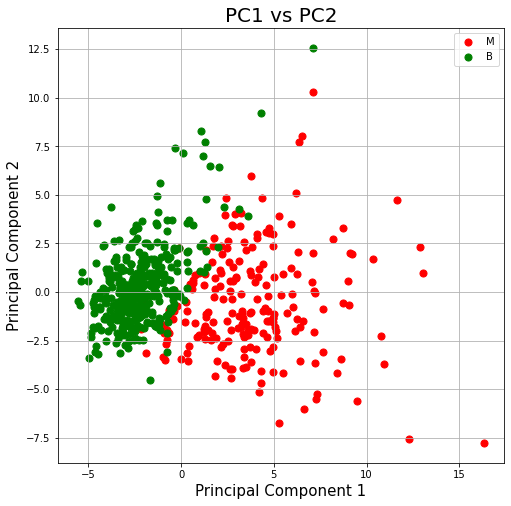

```python
import matplotlib.pyplot as plt
fig = plt.figure(figsize = (8,8))
ax = fig.add_subplot(1,1,1)
ax.set_xlabel('Principal Component 1', fontsize = 15)
ax.set_ylabel('Principal Component 2', fontsize = 15)
ax.set_title('PC1 vs PC2', fontsize = 20)
targets = ['M','B']
colors = ['r', 'g']
for target, color in zip(targets,colors):
    indicesToKeep = finalDf['diagnosis'] == target
    ax.scatter(finalDf.loc[indicesToKeep, 'principal component 1']
               , finalDf.loc[indicesToKeep, 'principal component 2']
               , c = color
               , s = 50)
ax.legend(targets)
ax.grid()
```

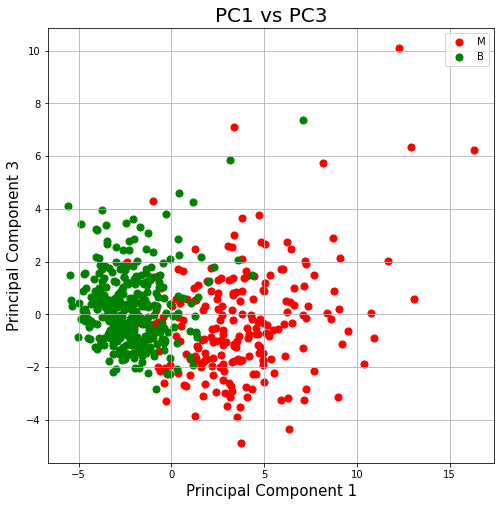

```python
fig = plt.figure(figsize = (8,8))
ax = fig.add_subplot(1,1,1)
ax.set_xlabel('Principal Component 1', fontsize = 15)
ax.set_ylabel('Principal Component 3', fontsize = 15)
ax.set_title('PC1 vs PC3', fontsize = 20)
targets = ['M','B']
colors = ['r', 'g']
for target, color in zip(targets,colors):
    indicesToKeep = finalDf['diagnosis'] == target
    ax.scatter(finalDf.loc[indicesToKeep, 'principal component 1']
               , finalDf.loc[indicesToKeep, 'principal component 3']
               , c = color
               , s = 50)
ax.legend(targets)
ax.grid()
```

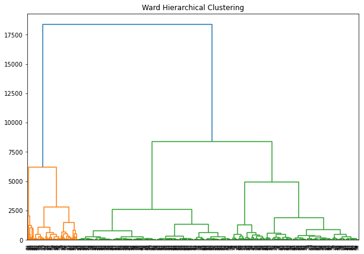

```python
import scipy.cluster.hierarchy as shc
data = cancer.iloc[:, 2:31].values
plt.figure(figsize=(10, 7))
plt.title("Ward Hierarchical Clustering")
dend1 = shc.dendrogram(shc.linkage(data, method='ward'))
```

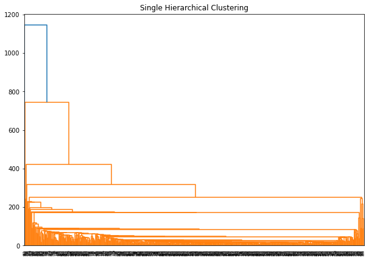

```python
data = cancer.iloc[:, 2:31].values
plt.figure(figsize=(10, 7))
plt.title("Single Hierarchical Clustering")
dend2 = shc.dendrogram(shc.linkage(data, method='single'))
```

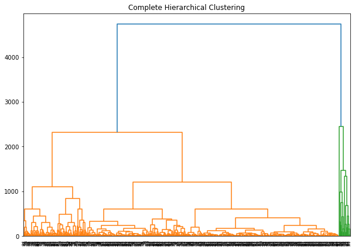

```python
data = cancer.iloc[:, 2:31].values
plt.figure(figsize=(10, 7))
plt.title("Complete Hierarchical Clustering")
dend3 = shc.dendrogram(shc.linkage(data, method='complete'))
```

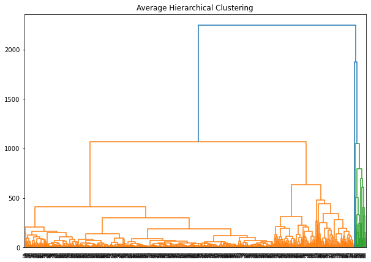

```python
data = cancer.iloc[:, 2:31].values
plt.figure(figsize=(10, 7))
plt.title("Average Hierarchical Clustering")
dend4 = shc.dendrogram(shc.linkage(data, method='average'))
```

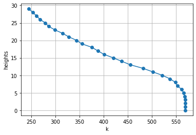

```python
from scipy.cluster.hierarchy import linkage, cut_tree
cancer2 = cancer.drop(['id'], axis = 1)
cancer3 = cancer2.drop(['diagnosis'], axis = 1)
hegits = np.arange(0, 30)
n_clusters = np.zeros(len(hegits))
linked = linkage(cancer3, metric="euclidean", method="average")

for i, d in enumerate(hegits):
    t = cut_tree(linked, height=d)
    n_clusters[i] = len(np.unique(t))

plt.plot(n_clusters, hegits, '-o')
plt.grid()
plt.xlabel('k')
plt.ylabel('heights')
```

Q9) No, you can not find by cutting into a different number of clusters as the hierarchical clustering method requires total input from all aspects of the dataframe in order to seperate into the hierarchical structure.

Q10) Our favorite one was probably the ward method. We thought that this method gave the cleanest looking clustering graph, with nice seperation. This was overall pretty to look at as it showed all aspects of clearly being visually aesthetic.